# Finding Best Value Books with Web Scraping

Yuchen Chen

2026-10-26

# Finding Best Value Books with Web Scraping

## Introduction

In the context of purchasing book online, consumers always find it difficult to tell the true value of the books. The public always have a misunderstanding that the more expensive books are more valuable, which is not necessarily true. The real data of the purchase of books is usually not like that. Some books with a low price have a high rating by the readers, while many expensive ones receive a lower rating. It is not enough if we only sort books by rating, because sorting by rating cannot consider how much money we spend to get that rating.

In this blog, I would explain the process of using the technique of scraping in the R code to scrape the data of the public books in a book website, including the book name, the book price and the reader rating of the book. The website I scrape is books.toscrape.com. The core goal of the analysis is very clear, no longer depends simply upon the price or the rating of the books to judge the value of them, but to construct a value index to sort the best books which have a higher rating with a lower price, and provide a helpful and useful purchase suggestion for the readers.

## Data Dealing and Analysis Methods

```r
page <- read_html("https://books.toscrape.com/catalogue/page-1.html")
titles <- page %>% html_elements("article.product_pod h3 a") %>% html_attr("title")
prices <- page %>% html_elements("p.price_color") %>% html_text2()
rating <- page %>% html_elements("p.star-rating") %>% html_attr("class")

books_df <- data.frame(
  book_title = titles,
  book_price = prices,
  book_rating = rating
)
books_df
```

```
##                                                                                        book_title
## 1                                                                            A Light in the Attic
## 2                                                                              Tipping the Velvet
## 3                                                                                      Soumission
## 4                                                                                   Sharp Objects
## 5                                                           Sapiens: A Brief History of Humankind
## 6                                                                                 The Requiem Red
## 7                                              The Dirty Little Secrets of Getting Your Dream Job
## 8         The Coming Woman: A Novel Based on the Life of the Infamous Feminist, Victoria Woodhull
## 9  The Boys in the Boat: Nine Americans and Their Epic Quest for Gold at the 1936 Berlin Olympics
## 10                                                                                The Black Maria
## 11                                                 Starving Hearts (Triangular Trade Trilogy, #1)
## 12                                                                          Shakespeare's Sonnets
## 13                                                                                    Set Me Free
## 14                                        Scott Pilgrim's Precious Little Life (Scott Pilgrim #1)
```

[output cut: 27 more lines]

In order to measure the value for money, I constructed the specific value index of the books, to divide the rating of the books by their prices. A higher value index of the book means the every unit of money spent for this book, the feedback recieved by the readers is higher, and the value for money is also higher.

After finishing the data cleaning, I sorted all the books from high to low considering their value index, and selected the top ten books with the highest value of money, and also draw a scatter plot of the price against rating in order to observe the overall relationship of the price and the rating of the books.

```r
books_clean <- books_df
books_clean$price_num <- as.numeric(sub("£","",books_clean$book_price))

books_clean$score <- NA
books_clean$score[endsWith(books_clean$book_rating, "One")] <- 1
books_clean$score[endsWith(books_clean$book_rating, "Two")] <- 2
books_clean$score[endsWith(books_clean$book_rating, "Three")] <- 3
books_clean$score[endsWith(books_clean$book_rating, "Four")] <- 4
books_clean$score[endsWith(books_clean$book_rating, "Five")] <- 5

books_clean$value_index <- books_clean$score / books_clean$price_num

books_sorted <- books_clean[order(-books_clean$value_index), ]
top10_books <- head(books_sorted, 10)
books_clean
```

```
##                                                                                        book_title
## 1                                                                            A Light in the Attic
## 2                                                                              Tipping the Velvet
## 3                                                                                      Soumission
## 4                                                                                   Sharp Objects
## 5                                                           Sapiens: A Brief History of Humankind
## 6                                                                                 The Requiem Red
## 7                                              The Dirty Little Secrets of Getting Your Dream Job
## 8         The Coming Woman: A Novel Based on the Life of the Infamous Feminist, Victoria Woodhull
## 9  The Boys in the Boat: Nine Americans and Their Epic Quest for Gold at the 1936 Berlin Olympics
## 10                                                                                The Black Maria
## 11                                                 Starving Hearts (Triangular Trade Trilogy, #1)
## 12                                                                          Shakespeare's Sonnets
## 13                                                                                    Set Me Free
## 14                                        Scott Pilgrim's Precious Little Life (Scott Pilgrim #1)
```

[output cut: 27 more lines]

## Analysis of the Research Result

The visualized graph clearly indicates that the price of the books and the readers’ rating have no positive relationship. The expensive books does not necessarilly have a high rating, and vice versa, the cheap books also have high quality ones, which totally rule out the opinion that the expensive one is better.

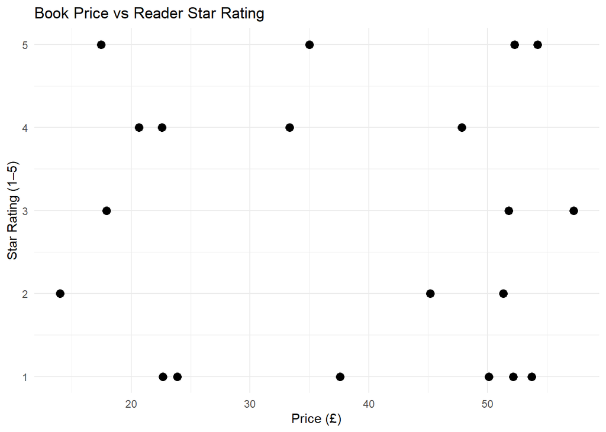

```r
if (!dir.exists("figures")) dir.create("figures")

p <- ggplot(books_clean, aes(x = price_num, y = score)) +
  geom_point(size=3) +
  labs(title = "Book Price vs Reader Star Rating",
       x = "Price (£)",
       y = "Star Rating (1–5)") +
  theme_minimal()

ggsave("figures/book_scatter.png", plot = p, width = 6, height = 4)
print(p)
```

```r
print("Top 10 books with highest value index:")
```

```
## [1] "Top 10 books with highest value index:"
```

```r
print(top10_books[,c("book_title","price_num","score","value_index")])
```

```
##                                                                                        book_title
## 13                                                                                    Set Me Free
## 12                                                                          Shakespeare's Sonnets
## 9  The Boys in the Boat: Nine Americans and Their Epic Quest for Gold at the 1936 Berlin Olympics
## 8         The Coming Woman: A Novel Based on the Life of the Infamous Feminist, Victoria Woodhull
## 11                                                 Starving Hearts (Triangular Trade Trilogy, #1)
## 15                                                                      Rip it Up and Start Again
## 7                                              The Dirty Little Secrets of Getting Your Dream Job
## 14                                        Scott Pilgrim's Precious Little Life (Scott Pilgrim #1)
## 5                                                           Sapiens: A Brief History of Humankind
## 4                                                                                   Sharp Objects
##    price_num score value_index
## 13     17.46     5  0.28636884
## 12     20.66     4  0.19361084
## 9      22.60     4  0.17699115
## 8      17.93     3  0.16731735
## 11     13.99     2  0.14295926
## 15     35.02     5  0.14277556
## 7      33.34     4  0.11997600
## 14     52.29     5  0.09562058
## 5      54.23     5  0.09219989
## 4      47.82     4  0.08364701
```

## Conclusion

Throughout this data analysis, I learned how to use the method of scratching to obtain the public data of the website, and finish real life analysis by data cleaning, index constructing and sorting statistics.

In our real life we always have bias by using our objective experience to make judgement on the stuffs, while data analysis can provide us with subjective evidence. This experiment proved that when we purchase a product, we cannot judge it simply by its price. If you have tight budget on buying books, you can start your search from this top-value list. Do not automatically think expensive books are better. Through data analysis we can easily sort and find out the best choice. This analytical logic can not only used in purchasing books, but also applied in all the consuming scenes, and help us realize the rational consumption.